# PRACTICUM 1: GROUP – AG 18

## GROUP MEMBERS

##### 1: Mudit Bhartia

##### 2: Savitha Munirajaiah

##### 3: Shubham Arora

### USE CASE

Lets consider we have a mobile application which help users register themselves and upload their COVID -19 test reports. Results of this report could be positive or negative, and some users may have registered but not tested yet.

When a user is tested positive a case is logged in a case management database, which helps contact tracing team manage their cases. The lifecycle of a case is Open, Assigned, WorkInProgress, and Closed. Contact Tracing team’s primary goal is to identify the contacts made by the user tested positive. As part of the case, they make contact with these exposed people who could be infected and warm them and the risks involved and advice to stay quarantined. The health worked follows up both the patient and the contacts involved in his/her cases frequently and ensure their well-being, and avoid further spread of infection. The team also tracks the area infected and their contamination level.

### 1. UML Class Diagram

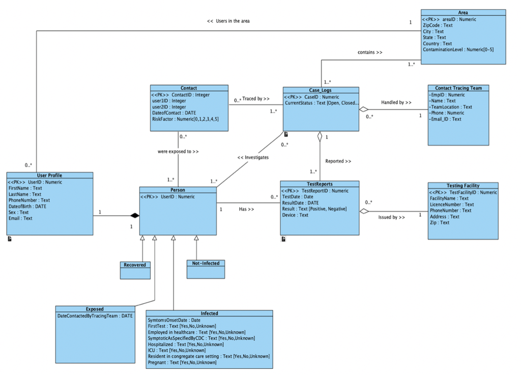

Conceptual Model

#### Assumptions

1: A Person may or may not be tested for COVID-19

2: Assuming infected person remembers the contacts made.

3: Currently, assuming Infected persons have not travelled anywhere due to travel ban/ Lockdown.

4: We are not monitoring the personal relations between Infected person and contacts made.

### 2. Table definition

1. User Profile: - Contains personal information of the Patients/Users/Persons.
2. Person: - Specifies if a user is Infected, Not-Infected, Recovered or Exposed to an infected person. Each user is linked to their personal information table. It also contains basic information collected before Test is conducted for COVID-19.
3. Contacts: - This entity gives us the details about the people who have made a direct or an indirect contact with the infected person.
4. Areas Exposed: - This entity gives us information about the regions which have been affected by the covid19 virus. One of the key attributes here is the “contamination level”, which tells us about the degree of exposure on a scale of 1 to 5, with 1 being the lowest.
5. Case Logs: - This entity is designed to keep a record of all the cases which are registered in the application.
6. Contact Tracing Team: - This entity gives us information about the health workers who are working on different cases which are present with an active/open status in the case logs.
7. Test Reports: - This entity contains COVID-19 test reports of the users who have taken the test. It has an attribute called result, which gives us the information that which all patients have been infected by the virus.
8. Testing Facility: - This entity contains the details the labs which are involved in the testing of the patients.

### 3. Logical Data Model in Crow’s Feet, ERD

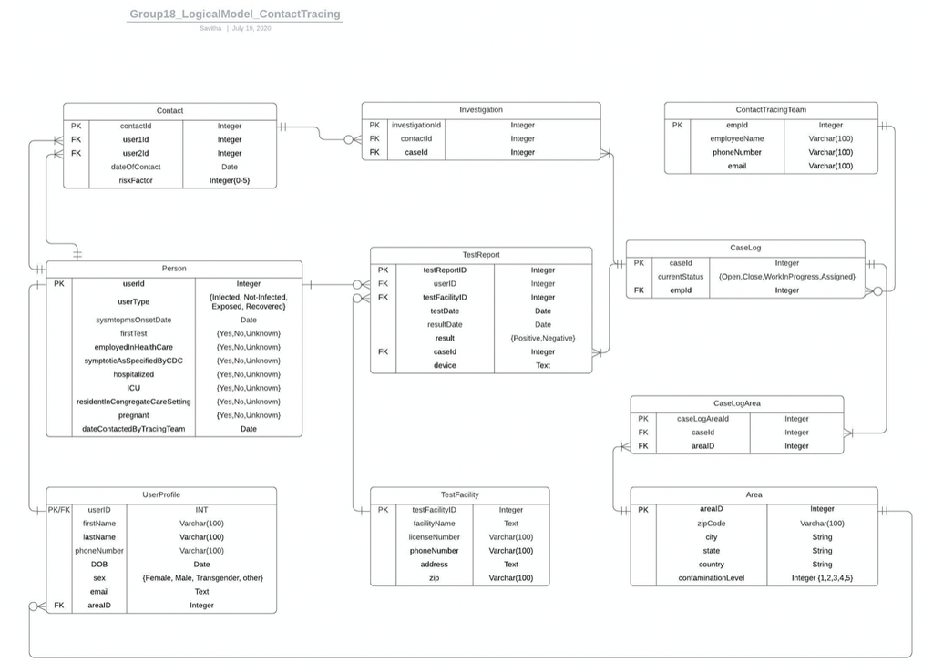

Logical Model

Link: - https://app.lucidchart.com/invitations/accept/116e355d-4c4d-4ef9-860c-f5d8b176828c

### 4. Definition of relational schema with proof that it is in BCNF.

Functional Dependencies:-

1. Contact Table

contactId -> user1Id, user2Id, dateOfContact, riskFactor.

2. Investigation Table

investigationId -> contactId, caseId.

3. ContactTractingTean Table

empId -> employeeName, phoneNumber, email.

4. Person Table

userId -> userType, sysmtopmsOnsetDate, firstTest , employedInHealthCare, symptoticAsSpecifiedByCDC, hospitalized , ICU , residentInCongregateCareSetting, pregnant, dateContactedByTracingTeam.

5. TestReport

testReportID -> userID, testFacilityID, testDate, resultDate, result, caseID, device.

6. CaseLog Table

caseId -> currentStatus, empId.

7. UserProfile Table

userID -> firstName, lastName, phoneNumber, DOB, sex, email, areaID.

8. TestFacility Table

testFacilityID -> facilityName, licenseNumber, phoneNumber, address, zip.

1. CaseLogArea Table

caseLogAreaId -> caseId, areaID.

10. Area Table

areaID -> zipCode, city, state, country, contaminationLevel.

In the tables above,

- Every attribute is atomic.
- Attributes are not partially dependent on candidate key/ composite key.
- There are no transitive dependencies within the attributes, they were resolved by creating separate entities.
- Every attribute of a table is determined only by its primary key. No other prime attribute can be used to derive non-prime attribute. Hence, the tables satisfy 1NF, 2NF, 3NF and are in BCNF .

### Database Schema- CREATE TABLE COMMANDS

```
CREATE TABLE PERSON (
    userId    INT AUTO_INCREMENT,
    userType    VARCHAR(20),
    symptomsOnsetDate    DATE,
    firstTest    VARCHAR(10) ,
    employedInHealthCare    VARCHAR(10),
    symptoticAsSpecifiedByCDC    VARCHAR(10) ,
    hospitalized    VARCHAR(10) ,
    ICU    VARCHAR(10) ,
    residentInCongregateCareSetting    VARCHAR(10) ,
    pregnant    VARCHAR(10) ,
    dateContactedByTracingTeam    DATE,
    CONSTRAINT PRIMARY KEY( userId ),
    CONSTRAINT CHECK (userType IN ("Infected","Not-Infected","Recovered","Exposed")),
    CONSTRAINT CHECK (firstTest IN ("Yes","No","Unknown")),
    CONSTRAINT CHECK (employedInHealthCare IN ("Yes","No","Unknown")),
    CONSTRAINT CHECK (symptoticAsSpecifiedByCDC IN ("Yes","No","Unknown")),
    CONSTRAINT CHECK (hospitalized IN ("Yes","No","Unknown")),
    CONSTRAINT CHECK (residentInCongregateCareSetting IN ("Yes","No","Unknown")),
    CONSTRAINT CHECK (pregnant IN ("Yes","No","Unknown")),
    CONSTRAINT CHECK (ICU IN ("Yes","No","Unknown"))
);


CREATE TABLE AREA (
    areaId    INT AUTO_INCREMENT,
    zipCode VARCHAR(100),
    city    VARCHAR(100),
    state    VARCHAR(100),
    country    VARCHAR(100),
    contaminationLevel INT ,
    PRIMARY KEY( areaId ),
    CONSTRAINT CHECK (contaminationLevel between 1 and 5)
);

CREATE TABLE TestFacility (
            testFacilityID Integer primary key,
                            facilityName Text,
                            licenseNumber varchar(100),
                            phoneNumber VARCHAR(100),
```

[output cut: 59 more lines]

```
    sex VARCHAR(20) ,
    email VARCHAR(100),
    areaId INT,
    CONSTRAINT PK1 PRIMARY KEY( userId ),
    CONSTRAINT FUP_P FOREIGN KEY(userId) REFERENCES PERSON(userId),
    CONSTRAINT FUP_A FOREIGN KEY(areaId) REFERENCES AREA(areaId),
    CONSTRAINT CHECK (sex IN ("Female","Male","Transgender","Other")));

CREATE TABLE CASELOGAREA (
    caseLogAreaId    INT AUTO_INCREMENT,
    caseId    INT NOT NULL,
    areaId    INT NOT NULL,
    PRIMARY KEY( caseLogAreaId ),
    CONSTRAINT FCLA_CL FOREIGN KEY(caseId) REFERENCES CASELOG(caseId),
    CONSTRAINT FCLA_A FOREIGN KEY(areaId) REFERENCES AREA(areaId));
```

### SQL Statements (Insertion):-

```
INSERT INTO `PERSON` (`userId`,`userType`,`symptomsOnsetDate`,`firstTest`,`employedInHealthCare`,`symptoticAsSpecifiedByCDC`,`hospitalized`,`ICU`,`residentInCongregateCareSetting`,`pregnant`,`dateContactedByTracingTeam`) VALUES (1,"Not-Infected","2020-03-25","UNKNOWN","NO","NO","UNKNOWN","YES","NO",…
INSERT INTO `PERSON` (`userId`,`userType`,`symptomsOnsetDate`,`firstTest`,`employedInHealthCare`,`symptoticAsSpecifiedByCDC`,`hospitalized`,`ICU`,`residentInCongregateCareSetting`,`pregnant`,`dateContactedByTracingTeam`) VALUES (11,"Infected","2019-11-07","UNKNOWN","UNKNOWN","NO","UNKNOWN","NO","YES…
INSERT INTO `PERSON` (`userId`,`userType`,`symptomsOnsetDate`,`firstTest`,`employedInHealthCare`,`symptoticAsSpecifiedByCDC`,`hospitalized`,`ICU`,`residentInCongregateCareSetting`,`pregnant`,`dateContactedByTracingTeam`) VALUES (21,"Infected","2019-07-04","UNKNOWN","NO","NO","NO","YES","YES","NO","2…
INSERT INTO `PERSON` (`userId`,`userType`,`symptomsOnsetDate`,`firstTest`,`employedInHealthCare`,`symptoticAsSpecifiedByCDC`,`hospitalized`,`ICU`,`residentInCongregateCareSetting`,`pregnant`,`dateContactedByTracingTeam`) VALUES (31,"Exposed","2019-09-22","YES","UNKNOWN","YES","YES","NO","NO","NO","2…
INSERT INTO `PERSON` (`userId`,`userType`,`symptomsOnsetDate`,`firstTest`,`employedInHealthCare`,`symptoticAsSpecifiedByCDC`,`hospitalized`,`ICU`,`residentInCongregateCareSetting`,`pregnant`,`dateContactedByTracingTeam`) VALUES (41,"Infected","2020-05-25","UNKNOWN","UNKNOWN","NO","YES","NO","UNKNOWN…
INSERT INTO `PERSON` (`userId`,`userType`,`symptomsOnsetDate`,`firstTest`,`employedInHealthCare`,`symptoticAsSpecifiedByCDC`,`hospitalized`,`ICU`,`residentInCongregateCareSetting`,`pregnant`,`dateContactedByTracingTeam`) VALUES (51,"Not-Infected","2020-04-16","YES","UNKNOWN","UNKNOWN","UNKNOWN","YES…
INSERT INTO `PERSON` (`userId`,`userType`,`symptomsOnsetDate`,`firstTest`,`employedInHealthCare`,`symptoticAsSpecifiedByCDC`,`hospitalized`,`ICU`,`residentInCongregateCareSetting`,`pregnant`,`dateContactedByTracingTeam`) VALUES (61,"Not-Infected","2020-07-02","NO","NO","UNKNOWN","NO","NO","UNKNOWN",…
INSERT INTO `PERSON` (`userId`,`userType`,`symptomsOnsetDate`,`firstTest`,`employedInHealthCare`,`symptoticAsSpecifiedByCDC`,`hospitalized`,`ICU`,`residentInCongregateCareSetting`,`pregnant`,`dateContactedByTracingTeam`) VALUES (71,"Recovered","2019-09-18","NO","YES","UNKNOWN","UNKNOWN","NO","UNKNOW…
INSERT INTO `PERSON` (`userId`,`userType`,`symptomsOnsetDate`,`firstTest`,`employedInHealthCare`,`symptoticAsSpecifiedByCDC`,`hospitalized`,`ICU`,`residentInCongregateCareSetting`,`pregnant`,`dateContactedByTracingTeam`) VALUES (81,"Infected","2019-05-29","NO","YES","UNKNOWN","YES","YES","NO","NO","…
INSERT INTO `PERSON` (`userId`,`userType`,`symptomsOnsetDate`,`firstTest`,`employedInHealthCare`,`symptoticAsSpecifiedByCDC`,`hospitalized`,`ICU`,`residentInCongregateCareSetting`,`pregnant`,`dateContactedByTracingTeam`) VALUES (91,"Not-Infected","2019-07-15","NO","UNKNOWN","NO","UNKNOWN","YES","YES…


INSERT INTO `Area` (`areaID`,`zipCode`,`city`,`state`,`country`,`contaminationLevel`) VALUES (1,"67548","Rhayader","P.O. Box 217, 336 Ac Avenue","Pitcairn Islands",5),(2,"796515","Korbach","6357 Lobortis Rd.","Slovenia",3),(3,"22725","Duncan","423-1926 Pede. Road","Malawi",2),(4,"0750","Hohenems","A…
INSERT INTO `userprofile` (`userId`,`firstName`,`lastName`,`phoneNumber`,`DOB`,`sex`,`email`,`areaId`) VALUES (1,"Kimberly","Baxter","3846187265","1991-06-27","Other","euismod.enim.Etiam@Donec.co.uk",6),(2,"Risa","Best","0957083329","2019-07-16","Transgender","ligula@aodiosemper.edu",82),(3,"Armando…
INSERT INTO `userprofile` (`userId`,`firstName`,`lastName`,`phoneNumber`,`DOB`,`sex`,`email`,`areaId`) VALUES (11,"Merrill","Frederick","4615865156","1962-01-04","Transgender","Curabitur@Vestibulumanteipsum.org",27),(12,"Nigel","Lowe","7572504643","1990-01-24","Male","tempor.augue.ac@nonnisiAenean.c…
INSERT INTO `userprofile` (`userId`,`firstName`,`lastName`,`phoneNumber`,`DOB`,`sex`,`email`,`areaId`) VALUES (21,"Elaine","Marsh","2319887056","1969-11-03","Female","magna.Ut.tincidunt@Proineget.net",88),(22,"Keely","Ward","9904009481","2010-09-06","Transgender","fringilla.cursus.purus@posuerecubil…
INSERT INTO `userprofile` (`userId`,`firstName`,`lastName`,`phoneNumber`,`DOB`,`sex`,`email`,`areaId`) VALUES (31,"Jin","Stephenson","7912877359","1960-09-11","Other","quam.vel.sapien@Etiam.com",54),(32,"Randall","Farmer","4861923609","2019-12-17","Female","non@eratEtiamvestibulum.co.uk",31),(33,"Hi…
```

[output cut: 44 more lines]